# Introduction to R and RStudio

Edinburgh Stats Team

DPUK Spring Academy 2025

## 1 Installing and Updating R, RStudio, and R packages

Detailed installation instructions can be found [on this webpage](https://uoepsy.github.io/scs/dpuk/install-update-r.html).

### 1.1 Installing R

- **Windows:**
  - Uninstall any previous R and Rtools installations.
  - Download installer: https://cran.r-project.org/bin/windows/base/R-4.4.3-win.exe.
  - For RTools (64-bit): https://cran.r-project.org/bin/windows/Rtools/rtools44/files/rtools44-aarch64-6459-6401.exe; for older PCs, see available 32-bit versions.
- **Apple macOS:**
  - Remove any previous R and XQuartz installations from Applications.
  - Download installer for your processor:
    - If Apple M1-M4: https://cran.r-project.org/bin/macosx/big-sur-arm64/base/R-4.4.3-arm64.pkg.
    - If Intel-based: https://cran.r-project.org/bin/macosx/big-sur-x86_64/base/R-4.4.3-x86_64.pkg.
  - Install XQuartz: https://xquartz.macosforge.org/.
- **Chromebooks:**
  - R cannot be installed; use Posit Cloud (https://posit.cloud/).

### 1.2 Installing RStudio

- **Windows & macOS:**
  - Download RStudio Desktop from https://posit.co/download/rstudio-desktop/ and follow the installation instructions.
- **Chromebooks:**
  - RStudio is unavailable; use Posit Cloud (https://posit.cloud/).

### 1.3 Updating R

- **Windows:**
  - In RStudio run:

    ```r
    install.packages("installr")
    installr::updateR()
    ```

- **Apple macOS:**
  - Remove the old R from Applications and reinstall using the appropriate installer.

### 1.4 Updating RStudio

- Check via Help > Check for updates. If an update is available, uninstall RStudio, and then install RStudio again.

### 1.5 Updating R Packages

- In RStudio run:

  ```r
  options(pkgType = "binary")
  update.packages(ask = FALSE)
  ```

## 2 Introduction to R and RStudio

RStudio Panes and Interface

- **Console:** Execute commands interactively. To execute code, press Enter.
- **Editor:** Write, modify, and save your R code. Press `Ctrl+Enter` or `Cmd+Enter` to send code to the Console for execution.
- **Environment:** View your current objects and variables.
- **Files, Plots, Packages, and Help:** Access your files, see your plots, and access the help page. Install/update packages (more on this later).

Console vs R scripts vs Rmarkdown (.Rmd) files

- **Console:** The Console is used for running commands interactively. It is great for quick calculations or testing small pieces of code, but it does not save your work. Once you close RStudio, the commands in the Console are lost unless explicitly saved elsewhere.
- **R Scripts (.R files):** R scripts are plain text files where you can write and save R code. They are ideal for creating reusable code and documenting your workflow. You can execute code from an R script by sending it to the Console (e.g., using `Ctrl+Enter` or `Cmd+Enter`).
- **RMarkdown (.Rmd files):** RMarkdown files combine code, text, and output in a single document. They are used for creating dynamic reports, presentations, or documents that include both analysis and narrative. You can execute code chunks within an RMarkdown file and render the document into formats like HTML, PDF, or Word.

Code vs Comments (vs Text in Rmarkdown)

- **Code:** Code is the actual R commands that are executed to perform tasks. In R scripts, code is written directly in the file. In RMarkdown, code is written inside code chunks (e.g., `` ```{r} ... ``` ``).
- **Text in RMarkdown:** In RMarkdown, text outside of code chunks is treated as narrative or explanatory text. It is written in Markdown syntax and is used to provide context, explanations, or documentation alongside the code and its output.
- **Comments:** Comments are lines of text in R scripts (or in RMarkdown code chunks) that are not executed as code. They are used to explain or document the code. In R, comments start with `#`. For example:

  ```r
  # This is a comment
  x <- 5  # Assign 5 to x
  ```

## 3 Basic R Functionality

### 3.1 Arithmetic and Calculations

R can perform basic arithmetic operations. Here are some examples:

```r
1 + 2   # Addition
```

```
## [1] 3
```

```r
5 - 3   # Subtraction
```

```
## [1] 2
```

```r
2 * 3   # Multiplication
```

```
## [1] 6
```

```r
1 / 2   # Division
```

```
## [1] 0.5
```

```r
# Exponentiation
2^3
```

```
## [1] 8
```

```r
# Square roots
sqrt(4)
```

```
## [1] 2
```

```r
9^(1/2)
```

```
## [1] 3
```

```r
# Standard functions such as log(), exp(), log10() also exist
```

Remember, order of operations matters! Use parentheses to ensure the correct order.

```r
# This will give different results
(1 + 2) * 3   # Parentheses first
```

```
## [1] 9
```

```r
1 + 2 * 3     # Multiplication first
```

```
## [1] 7
```

### 3.2 Getting help in R

```r
?sqrt
help(sqrt)
```

### 3.3 Logical values

```r
# Logical
TRUE
```

```
## [1] TRUE
```

```r
FALSE
```

```
## [1] FALSE
```

```r
!TRUE             # not operator
```

```
## [1] FALSE
```

```r
2 == 3            # equal to operator
```

```
## [1] FALSE
```

```r
2 != 2            # not equal to operator
```

```
## [1] FALSE
```

```r
!(2 == 2)
```

```
## [1] FALSE
```

```r
2 > 3
```

```
## [1] FALSE
```

```r
2 <= 3
```

```
## [1] TRUE
```

```r
(2 > 1) & (2 < 3) # and operator
```

```
## [1] TRUE
```

```r
(2 > 1) | (2 < 3) # or operator
```

```
## [1] TRUE
```

### 3.4 Variables and Assignment

Variables are used to store values.

Use `<-` or `=` for assignment into a name.

You can later retrieve the value by calling the variable name.

```r
x <- 5          # Assign 5 to x
y <- 10         # Assign 10 to y
total <- x + y  # Add x and y
total           # Output 15
```

```
## [1] 15
```

## 4 Vectors

Vectors are one-dimensional arrays that can hold numeric, character, or logical data. You can create vectors using the combine function, `c()`.

```r
# Creating a numeric vector
numbers <- c(1, 2, 3, 4, 5)

# Creating a character vector
characters <- c("apple", "banana", "cherry")

# Creating a logical vector
logicals <- c(TRUE, FALSE, TRUE)

# Accessing elements of a vector
numbers[1]       # First element
```

```
## [1] 1
```

```r
characters[2:3]  # Second and third elements
```

```
## [1] "banana" "cherry"
```

```r
logicals[c(1, 3)] # First and third elements
```

```
## [1] TRUE TRUE
```

```r
# Vectorized operations
numbers * 2       # Multiply each element by 2
```

```
## [1]  2  4  6  8 10
```

```r
numbers + 10      # Add 10 to each element
```

```
## [1] 11 12 13 14 15
```

```r
numbers > 3       # Logical comparison
```

```
## [1] FALSE FALSE FALSE  TRUE  TRUE
```

```r
# Member of a vector
"cherry" %in% characters
```

```
## [1] TRUE
```

## 5 Installing packages

In console:

```r
install.packages("palmerpenguins")
install.packages("tidyverse")
```

Using the Packages tab in RStudio.

## 6 Introduction to tidyverse

This is a brief overview of tidyverse, the set of packages for data science in R.

```r
# Load the tidyverse collection of packages
library(tidyverse)
```

`tidyverse` is a collection of packages which includes:

- `ggplot2` for data visualization
- `dplyr` for data manipulation
- `tidyr` for data tidying
- `readr` for data import
- `tibble` for data frames
- `stringr` for string manipulation
- `forcats` for categorical variables

and more…

The good news is: you don’t need to remember which package a function comes from. When you load the tidyverse, all of these packages are loaded at once.

You can find helpful cheatsheets [here](https://posit.co/resources/cheatsheets/).

## 7 palmerpenguins: A tidyverse data example

A demonstration using the `penguins` dataset, provided by the [palmerpenguins package](https://allisonhorst.github.io/palmerpenguins/index.html).

The `penguins` dataset contains 344 rows and 8 variables:

- `species` - a factor denoting penguin species (Adélie, Chinstrap and Gentoo)
- `island` - a factor denoting island in Palmer Archipelago, Antarctica (Biscoe, Dream or Torgersen)
- `bill_length_mm` - a number denoting bill length (millimeters)
- `bill_depth_mm` - a number denoting bill depth (millimeters)
- `flipper_length_mm` - an integer denoting flipper length (millimeters)
- `body_mass_g` - an integer denoting body mass (grams)
- `sex` - a factor denoting penguin sex (female, male)
- `year` - an integer denoting the study year (2007, 2008, or 2009)

```r
library(palmerpenguins)
library(tidyverse)

# Look at the first six rows of the dataset
head(penguins)
```

```
## # A tibble: 6 × 8
##   species island    bill_length_mm bill_depth_mm flipper_length_mm body_mass_g
##   <fct>   <fct>              <dbl>         <dbl>             <int>       <int>
## 1 Adelie  Torgersen           39.1          18.7               181        3750
## 2 Adelie  Torgersen           39.5          17.4               186        3800
## 3 Adelie  Torgersen           40.3          18                 195        3250
## 4 Adelie  Torgersen           NA            NA                  NA          NA
## 5 Adelie  Torgersen           36.7          19.3               193        3450
## 6 Adelie  Torgersen           39.3          20.6               190        3650
## # ℹ 2 more variables: sex <fct>, year <int>
```

```r
# Structure of dataset
str(penguins)
```

```
## tibble [344 × 8] (S3: tbl_df/tbl/data.frame)
##  $ species          : Factor w/ 3 levels "Adelie","Chinstrap",..: 1 1 1 1 1 1 1 1 1 1 ...
##  $ island           : Factor w/ 3 levels "Biscoe","Dream",..: 3 3 3 3 3 3 3 3 3 3 ...
##  $ bill_length_mm   : num [1:344] 39.1 39.5 40.3 NA 36.7 39.3 38.9 39.2 34.1 42 ...
##  $ bill_depth_mm    : num [1:344] 18.7 17.4 18 NA 19.3 20.6 17.8 19.6 18.1 20.2 ...
##  $ flipper_length_mm: int [1:344] 181 186 195 NA 193 190 181 195 193 190 ...
##  $ body_mass_g      : int [1:344] 3750 3800 3250 NA 3450 3650 3625 4675 3475 4250 ...
##  $ sex              : Factor w/ 2 levels "female","male": 2 1 1 NA 1 2 1 2 NA NA ...
##  $ year             : int [1:344] 2007 2007 2007 2007 2007 2007 2007 2007 2007 2007 ...
```

```r
# Summary of dataset
summary(penguins)
```

```
##       species          island    bill_length_mm  bill_depth_mm
##  Adelie   :152   Biscoe   :168   Min.   :32.10   Min.   :13.10
##  Chinstrap: 68   Dream    :124   1st Qu.:39.23   1st Qu.:15.60
##  Gentoo   :124   Torgersen: 52   Median :44.45   Median :17.30
##                                  Mean   :43.92   Mean   :17.15
##                                  3rd Qu.:48.50   3rd Qu.:18.70
##                                  Max.   :59.60   Max.   :21.50
##                                  NA's   :2       NA's   :2
##  flipper_length_mm  body_mass_g       sex           year
##  Min.   :172.0     Min.   :2700   female:165   Min.   :2007
##  1st Qu.:190.0     1st Qu.:3550   male  :168   1st Qu.:2007
##  Median :197.0     Median :4050   NA's  : 11   Median :2008
##  Mean   :200.9     Mean   :4202                Mean   :2008
##  3rd Qu.:213.0     3rd Qu.:4750                3rd Qu.:2009
##  Max.   :231.0     Max.   :6300                Max.   :2009
##  NA's   :2         NA's   :2
```

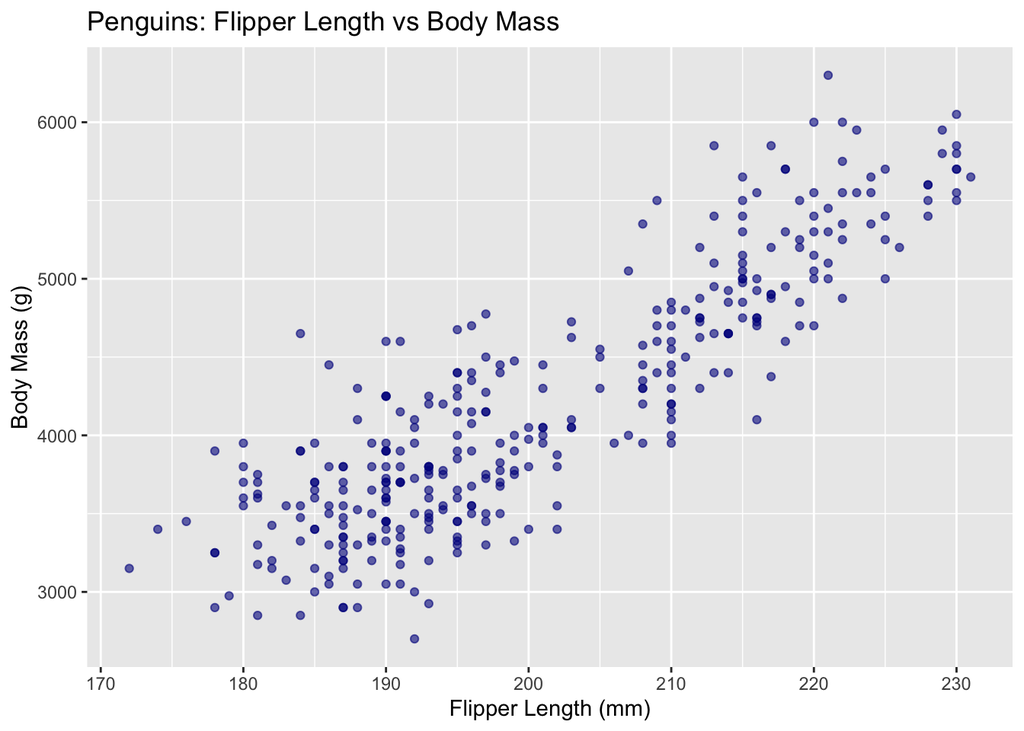

```r
# A scatterplot exploring penguin body mass vs flipper length
ggplot(penguins, aes(x = flipper_length_mm, y = body_mass_g)) +
  geom_point(color = "darkblue", alpha = 0.6) +
  labs(title = "Penguins: Flipper Length vs Body Mass",
       x = "Flipper Length (mm)",
       y = "Body Mass (g)")
```

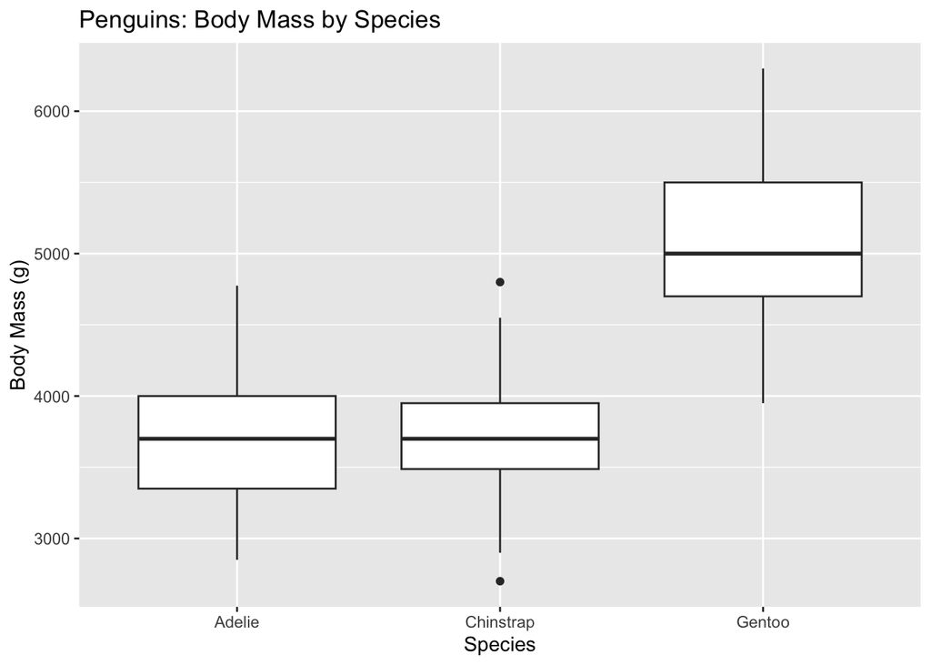

```r
# A boxplot to explore the association between body mass and species
ggplot(penguins, aes(x = species, y = body_mass_g)) +
  geom_boxplot() +
  labs(title = "Penguins: Body Mass by Species",
       x = "Species",
       y = "Body Mass (g)")
```

## 8 Data subsetting

```r
penguins[1, ]           # First row

penguins[, 1]           # First column - by number
penguins[ , "species"]  # First column - by name
penguins$species        # First column - by name

penguins[c(1,2,3), ]    # First three rows

penguins[, c(1,2,3)]    # First three columns - by number
penguins[, c("species", "island", "bill_length_mm")] # First three columns - by name

penguins[c(1,2,3), c(1,2,3)] # First three rows and columns and range shortcut
penguins[1:3, 1:3] # Shortcut : for range of consecutive values
```

```r
# Subset the data for only Adelie species
adelie_penguins <- penguins |>
  filter(species == "Adelie")

# Remove specific rows of the penguins dataset
!is.na(penguins$body_mass_g)    # returns TRUE/FALSE for each row

# Filter out rows with NA values in body_mass_g
penguins_no_na <- penguins |>
  filter( !is.na(body_mass_g) )

# Only keep columns species, body_mass_g
penguins_subset <- penguins_no_na |>
  select(species, body_mass_g)
```

## 9 Reading data into R

Consider [this dataset](https://raw.githubusercontent.com/allisonhorst/palmerpenguins/master/inst/extdata/penguins.csv)

A file path is a string that specifies the location of a file or directory in your computer’s file system. It tells your system how to navigate through folders to locate the file. There are two main types:

**Absolute Path:** Specifies the complete directory list from the root folder.

**Relative Path:** Specifies the location relative to the current file or folder.

Paths are essential for accessing or referencing files correctly in your code.

```r
# Read from local file
penguins_data <- read_csv("path/to/penguins.csv")

# Read from URL
penguins_data <- read_csv("https://raw.githubusercontent.com/allisonhorst/palmerpenguins/master/inst/extdata/penguins.csv")
```

The following functions are also available to read other types of files:

- `read_csv()` for CSV files
- `read_tsv()` for tab-separated files
- `read_excel()` for Excel files
- `library(haven)` and then
  - `read_dta()` for Stata files
  - `read_sav()` for SPSS files
  - `read_sas()` for SAS files

## 10 Summary & Questions

This introductory session builds the foundation in R and tidyverse for our forthcoming four days which will focus on the linear model.

- R & RStudio installation and interface.
- Basics of R with emphasis on tidyverse.
- A practical data example with palmerpenguins.
- Any questions?